# Exercise 2. Regression and model validation

*During this weeks work we learned some preprocessing of the data by scaling combination variables to original scales and excluding unneeded variables and observations from the data. Further we learned how to get overview of the data by calculating summary statistics and by making plots (e.g scatter plot). With regression model we learned to create a model to see which variables affected most to exam points. Validity of the selected regression model graphically exlored with residuals vs. fitted, quantile-quantile and residuals vs. leverage plots.*

```r
date()
```

```
## [1] "Thu Nov 05 16:25:48 2020"
```

```r
#### DATA ANALYSIS ####

#### TASK 1 ####
# reading in and structure of the data

# packages needed
library(data.table)
```

```r
library(ggplot2)
# Reading the learning 2014 data into R, using fread function of data.table package
learning2014 <- fread("E:/IODS_usb/IODS-project/data/learning2014.csv")

# structure and dimensions of the data
# data.frame with 166 obs. (students) of 7 variables (gender, age, attitude, deep, stra, surf, points)
str(learning2014)
```

```
## Classes 'data.table' and 'data.frame':   166 obs. of  7 variables:
##  $ gender  : chr  "F" "M" "F" "M" ...
##  $ age     : int  53 55 49 53 49 38 50 37 37 42 ...
##  $ attitude: num  3.7 3.1 2.5 3.5 3.7 3.8 3.5 2.9 3.8 2.1 ...
##  $ deep    : num  3.58 2.92 3.5 3.5 3.67 ...
##  $ stra    : num  3.38 2.75 3.62 3.12 3.62 ...
##  $ surf    : num  2.58 3.17 2.25 2.25 2.83 ...
##  $ points  : int  25 12 24 10 22 21 21 31 24 26 ...
##  - attr(*, ".internal.selfref")=<externalptr>
```

```r
dim(learning2014)
```

```
## [1] 166   7
```

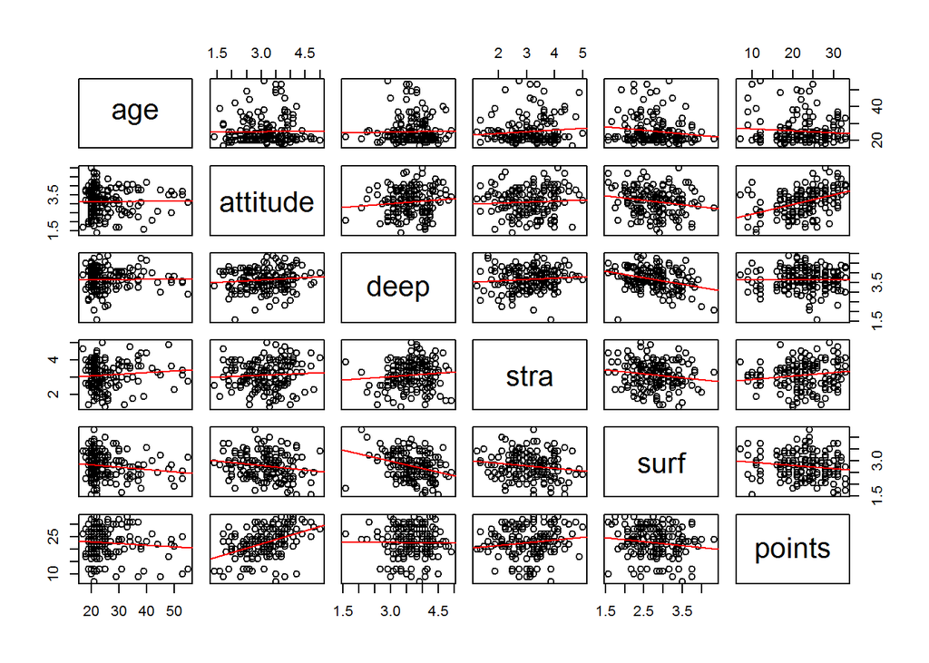

```r
#### TASK 2 ####
# a graphical overview and summaries of the data

# to fit the sraight line with lm in scatterplot matrix
# https://stackoverflow.com/questions/39667830/how-to-insert-trendlines-in-scatterplot-matrix

panel.lm <- function (x, y,  pch = par("pch"), col.lm = "red",  ...) {
  ymin <- min(y)
  ymax <- max(y)
  xmin <- min(x)
  xmax <- max(x)
  ylim <- c(min(ymin,xmin),max(ymax,xmax))
  xlim <- ylim
  points(x, y, pch = pch,ylim = ylim, xlim= xlim,...)
  ok <- is.finite(x) & is.finite(y)
  if (any(ok))
    abline(lm(y[ok]~ x[ok]),
           col = col.lm, ...)
}

# draw a scatter plot matrix of the variables in learning2014.
# [,2:7] excludes the first column (gender)
pairs(learning2014[,2:7], panel = panel.lm)
```

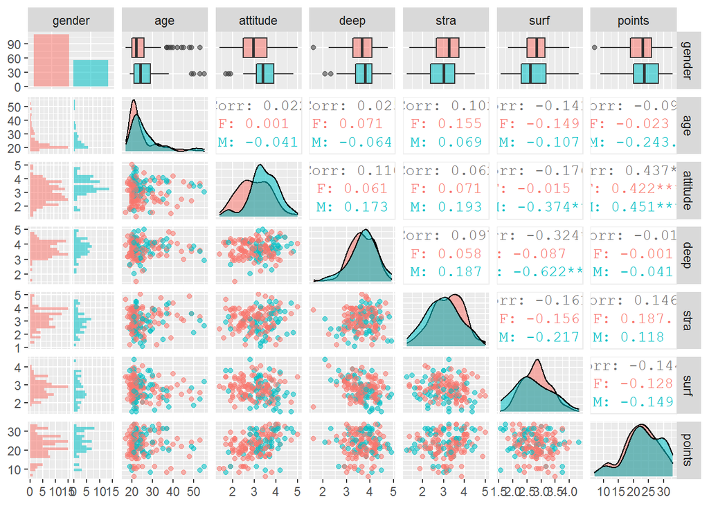

```r
# access the GGally and ggplot2 libraries
library(GGally)
library(ggplot2)

# create a more advanced plot matrix with ggpairs() and draw the plot. Divided by gender
p <- ggpairs(learning2014, mapping = aes(col = gender, alpha = 0.3), lower = list(combo = wrap("facethist", bins = 20)))
p
```

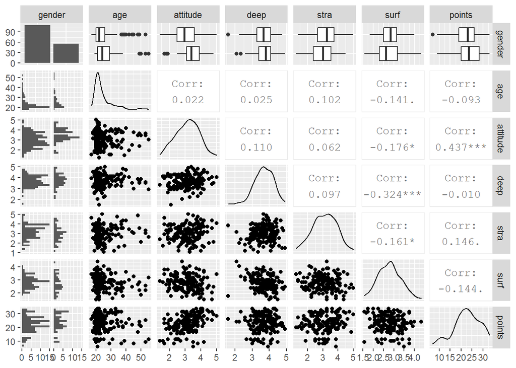

```r
# create an plot matrix with ggpairs(). All subjects
ggpairs(learning2014, lower = list(combo = wrap("facethist", bins = 20)))
```